# Assessment 1 - COVID-19 impact on digital learning

Viet Cuong Truong

2023-04-06

## Data Cleaning and Wrangling

Import libraries

```r
library(tidyverse)
```

```r
library(dplyr)
library(ggplot2)
library(viridis)
library(highcharter)
```

### Product files

Import the prodict_info file into the dataset

```r
#import file
products <- read_csv("products_info.csv",na = c("NaN", "Na"))
#show summary data of tibble
str(products)
```

```
## spc_tbl_ [372 × 6] (S3: spec_tbl_df/tbl_df/tbl/data.frame)
##  $ LP ID                     : num [1:372] 13117 66933 50479 92993 73104 ...
##  $ URL                       : chr [1:372] "https://www.splashmath.com" "https://abcmouse.com" "https://www.abcya.com" "http://www.aleks.com/" ...
##  $ Product Name              : chr [1:372] "SplashLearn" "ABCmouse.com" "ABCya!" "ALEKS" ...
##  $ Provider/Company Name     : chr [1:372] "StudyPad Inc." "Age of Learning, Inc" "ABCya.com, LLC" "McGraw-Hill PreK-12" ...
##  $ Sector(s)                 : chr [1:372] "PreK-122" "PreK-12" "PreK-12" "PreK-12; Higher Ed" ...
##  $ Primary Essential Function: chr [1:372] "LC - Digital Learning Platforms" "LC - Digital Learning Platforms" "LC - Sites, Resources & Reference - Games & Simulations" "LC - Digital Learning Platforms" ...
##  - attr(*, "spec")=
##   .. cols(
##   ..   `LP ID` = col_double(),
##   ..   URL = col_character(),
##   ..   `Product Name` = col_character(),
##   ..   `Provider/Company Name` = col_character(),
##   ..   `Sector(s)` = col_character(),
##   ..   `Primary Essential Function` = col_character()
##   .. )
##  - attr(*, "problems")=<externalptr>
```

```r
#inspect the data by printing the first few rows
head(products)
```

| LP ID | URL | Product Name | Provider/Company Name | Sector(s) | Primary Essential Function |
| --- | --- | --- | --- | --- | --- |
| 13117 | https://www.splashmath.com | SplashLearn | StudyPad Inc. | PreK-122 | LC - Digital Learning Platforms |
| 66933 | https://abcmouse.com | ABCmouse.com | Age of Learning, Inc | PreK-12 | LC - Digital Learning Platforms |
| 50479 | https://www.abcya.com | ABCya! | ABCya.com, LLC | PreK-12 | LC - Sites, Resources & Reference - Games & Simulations |
| 92993 | http://www.aleks.com/ | ALEKS | McGraw-Hill PreK-12 | PreK-12; Higher Ed | LC - Digital Learning Platforms |
| 73104 | https://www.achieve3000.com/ | Achieve3000 | Achieve3000 | PreK-12 | LC - Digital Learning Platforms |
| 37600 | http://www.activelylearn.com/ | Actively Learn | Actively Learn | PreK-12 | LC - Digital Learning Platforms |

Now we will clean the data. First, let’s examine if the dataset has null values

```r
#check if there are any missing values or NAs
any(is.na(products))
```

```
## [1] FALSE
```

Let see the Sector column

```r
unique(products$`Sector(s)`) #Sectors column
```

```
##  [1] "PreK-122"                      "PreK-12"
##  [3] "PreK-12; Higher Ed"            "PreK-12; Higher Ed; Corporate"
##  [5] "PreK-112"                      ""
##  [7] "Corporate"                     "Higher Ed; Corporate"
##  [9] "PreK-12; Higher; Corporate"    "PPreK-12"
```

There are lots of errors in the data that need cleaning. We will have to change “PreK-122”, “PreK-112”, “PPreK-12” to “PreK-12” and “PreK-12; Higher; Corporate” to “PreK-12; Higher Ed; Corporate”

```r
products_clean <- products %>%
  # change "PreK-122", "PreK-112", "PPreK-12" to "PreK-12"
  mutate(`Sector(s)` = ifelse(grepl("(PreK-122|PreK-112|PPreK-12)", `Sector(s)`, ignore.case = TRUE), "PreK-12",  `Sector(s)`),
  # change "PreK-12; Higher; Corporate" to "PreK-12; Higher Ed; Corporate"
         `Sector(s)` = ifelse(grepl("PreK-12; Higher; Corporate", `Sector(s)`, ignore.case = TRUE), "PreK-12; Higher Ed; Corporate",  `Sector(s)`))
unique(products_clean$`Sector(s)`) # check the unique data again in the Sector column
```

```
## [1] "PreK-12"                       "PreK-12; Higher Ed"
## [3] "PreK-12; Higher Ed; Corporate" ""
## [5] "Corporate"                     "Higher Ed; Corporate"
```

Our data appears to be ready. Let’s move on to Districts data

### District files

Import the prodict_info file into the dataset

```r
#import file
districts <- read_csv("districts_info.csv",na = c("NaN", "Na", ""))
#show summary data of tibble
str(districts)
```

```
## spc_tbl_ [233 × 7] (S3: spec_tbl_df/tbl_df/tbl/data.frame)
##  $ district_id             : num [1:233] 8815 2685 4921 3188 2238 ...
##  $ state                   : chr [1:233] "Illinois" NA "UTAH" NA ...
##  $ locale                  : chr [1:233] "Suburb" NA "Suburb" NA ...
##  $ pct_black/hispanic      : chr [1:233] "[0, 0.2[" NA "[0, 0.2[" NA ...
##  $ pct_free/reduced        : chr [1:233] "[0, 0.2[" NA "[0.2, 0.4[" NA ...
##  $ county_connections_ratio: chr [1:233] "[0.18, 1[" NA "[0.18, 1[" NA ...
##  $ pp_total_raw            : chr [1:233] "[14000, 16000[" NA "[6000, 8000[" NA ...
##  - attr(*, "spec")=
##   .. cols(
##   ..   district_id = col_double(),
##   ..   state = col_character(),
##   ..   locale = col_character(),
##   ..   `pct_black/hispanic` = col_character(),
##   ..   `pct_free/reduced` = col_character(),
##   ..   county_connections_ratio = col_character(),
##   ..   pp_total_raw = col_character()
##   .. )
##  - attr(*, "problems")=<externalptr>
```

```r
#inspect the data by printing the first few rows
head(districts)
```

| district_id | state | locale | pct_black/hispanic | pct_free/reduced | county_connections_ratio | pp_total_raw |
| --- | --- | --- | --- | --- | --- | --- |
| 8815 | Illinois | Suburb | [0, 0.2[ | [0, 0.2[ | [0.18, 1[ | [14000, 16000[ |
| 2685 | NA | NA | NA | NA | NA | NA |
| 4921 | UTAH | Suburb | [0, 0.2[ | [0.2, 0.4[ | [0.18, 1[ | [6000, 8000[ |
| 3188 | NA | NA | NA | NA | NA | NA |
| 2238 | NA | NA | NA | NA | NA | NA |
| 5987 | Wisconsin | Suburb | [0, 0.2[ | [0, 0.2[ | [0.18, 1[ | [10000, 12000[ |

There are lots of NA values in the dataset. Let’s see how many incomplete rows are in the districts dataset.

```r
# Calculate the number of rows with missing values in the "districts" data frame
sum(!complete.cases(districts))
```

```
## [1] 145
```

Remove all the NA, NAN and empty from the data

```r
# Remove null value
districts_clean <- na.omit(districts)
```

Here we have several variables that we will turn into factors.

* State, district_id, and locale are fairly self-explanatory.

* The pct_black.hispanic and pct_free.reduced variables appear to be ordered categorical variables that represent a percentage-group.

We will convert the various variables in this situation into factors.

```r
# check the unique data
unique(districts_clean$locale)
```

```
## [1] "Suburb" "Cit"    "Rural"  "City"   "Town"   "Sub"
```

Change the typo in the districts data

```r
# Locale
districts_clean <- districts_clean %>% mutate(locale = ifelse(locale == "Cit", "City",
                                          ifelse(locale == "Sub", "Suburb", locale)))
unique(districts_clean$locale) # check the data again
```

```
## [1] "Suburb" "City"   "Rural"  "Town"
```

Change the format and remove unwanted characters from PCT_black/hispanic column

```r
# Pct_black/hispanic
districts_clean$`pct_black/hispanic` <- str_trim(districts_clean$`pct_black/hispanic`) # remove white space
districts_clean$`pct_black/hispanic` <- ifelse(districts_clean$`pct_black/hispanic` == "[0, 0.2[" , "0-20%",
                                      (ifelse(districts_clean$`pct_black/hispanic` == "[0.2, 0.4[" , "20-40%",
                                              (ifelse(districts_clean$`pct_black/hispanic` == "[0.4, 0.6[" , "40-60%",
                                                      (ifelse(districts_clean$`pct_black/hispanic` == "[0.6, 0.8[" , "60-80%",
                                                              (ifelse(districts_clean$`pct_black/hispanic` == "[0.8, 1[" , "80-100%", NaN) )))))))) # change the data to percentage
```

Change the format and remove unwanted characters from Pct_free/reduced column

```r
# Pct_free/reduced
districts_clean$`pct_free/reduced` <- str_trim(districts_clean$`pct_free/reduced`) # remove white space
districts_clean$`pct_free/reduced` <- ifelse(districts_clean$`pct_free/reduced` == "[0, 0.2[" , "0-20%",
                                    (ifelse(districts_clean$`pct_free/reduced`== "[0.2, 0.4[" , "20-40%",
                                            (ifelse(districts_clean$`pct_free/reduced` == "[0.4, 0.6[" , "40-60%",
                                                    (ifelse(districts_clean$`pct_free/reduced` == "[0.6, 0.8[" , "60-80%",
                                                            (ifelse(districts_clean$`pct_free/reduced` == "[0.8, 1[" , "80-100%", NaN) )))))))) # change the data to percentage
```

Change the format and remove unwanted characters from PP_Total_raw column

```r
## PP_Total_raw
districts_clean$pp_total_raw <- gsub( "[", "", districts_clean$pp_total_raw, fixed = TRUE ) # replace "[" to " "
districts_clean$pp_total_raw <- gsub( ", ", "-", districts_clean$pp_total_raw, fixed = TRUE ) # replace "," to "-"
```

Change the format and remove unwanted characters from county connection ratio column

```r
## county connection ratio
districts_clean$county_connections_ratio <- gsub( "[", "", districts_clean$county_connections_ratio, fixed = TRUE ) # replace "[" to " "
districts_clean$county_connections_ratio <- gsub( ", ", "-", districts_clean$county_connections_ratio, fixed = TRUE )# replace "," to "-"
```

After cleaning the data, let’s see the districts data again

```r
head(districts_clean)
```

| district_id | state | locale | pct_black/hispanic | pct_free/reduced | county_connections_ratio | pp_total_raw |
| --- | --- | --- | --- | --- | --- | --- |
| 8815 | Illinois | Suburb | 0-20% | 0-20% | 0.18-1 | 14000-16000 |
| 4921 | UTAH | Suburb | 0-20% | 20-40% | 0.18-1 | 6000-8000 |
| 5987 | Wisconsin | Suburb | 0-20% | 0-20% | 0.18-1 | 10000-12000 |
| 3710 | Utah | Suburb | 0-20% | 40-60% | 0.18-1 | 6000-8000 |
| 7177 | North Carolina | Suburb | 20-40% | 20-40% | 0.18-1 | 8000-10000 |
| 9812 | Utah | City | 0-20% | 20-40% | 0.18-1 | 6000-8000 |

### Engagement files

```r
# import engagement data
Engagement_Data <- list.files("Engagement Data/")
Engagement_Data_2 <- paste0("Engagement Data//", Engagement_Data)

engage <- lapply(Engagement_Data_2, read_csv) %>%
  bind_rows(.id = "source")
head(engage)
```

| source | time | lp_id | pct_access | engagement_index |
| --- | --- | --- | --- | --- |
| 1 | 1/01/2020 | 93690 | 0.00 | NA |
| 1 | 1/01/2020 | 17941 | 0.03 | 0.90 |
| 1 | 1/01/2020 | 65358 | 0.03 | 1.20 |
| 1 | 1/01/2020 | 98265 | 0.57 | 37.79 |
| 1 | 1/01/2020 | 59257 | 0.00 | NA |
| 1 | 1/01/2020 | 90153 | 0.06 | 3.90 |

We will combine the data with the districts_file where the ID of an engagement matches the ID of a district. Then, we will merge this data with the products file where the lp_ID in the engagement file matches the Lp_id in the products file.

First we have to convert the Lp_id in the products table to lp_id

```r
names(products_clean)[1] <- "lp_id"
```

then we merge with 2 tables

```r
disctrict_joiner <- data.frame(district_id = districts_clean$district_id, source = as.character(1:nrow(districts_clean)))

engage <- engage %>%
  left_join(disctrict_joiner, by = "source")

engage <- engage %>%
  left_join(districts_clean, by = "district_id")

engage <- engage %>%
  left_join(products_clean, by = "lp_id")
```

Let’s see the first few rows of the engage dataset

```r
#inspect the data by printing the first few rows
head(engage)
```

| source | time | lp_id | pct_access | engagement_index | district_id | state | locale | pct_black/hispanic | pct_free/reduced | county_connections_ratio | pp_total_raw | URL | Product Name | Provider/Company Name | Sector(s) | Primary Essential Function |
| --- | --- | --- | --- | --- | --- | --- | --- | --- | --- | --- | --- | --- | --- | --- | --- | --- |
| 1 | 1/01/2020 | 93690 | 0.00 | NA | 8815 | Illinois | Suburb | 0-20% | 0-20% | 0.18-1 | 14000-16000 | http://www.calculator.com | Calculator.com | Calculator.com | PreK-12; Higher Ed; Corporate | LC - Sites, Resources & Reference |
| 1 | 1/01/2020 | 17941 | 0.03 | 0.90 | 8815 | Illinois | Suburb | 0-20% | 0-20% | 0.18-1 | 14000-16000 | https://www.kidsa-z.com/main/Login | Kids A-Z | Lazel Inc. | PreK-12 | LC - Digital Learning Platforms |
| 1 | 1/01/2020 | 65358 | 0.03 | 1.20 | 8815 | Illinois | Suburb | 0-20% | 0-20% | 0.18-1 | 14000-16000 | http://www.prezi.com | Prezi | Prezi Inc. | PreK-12; Higher Ed; Corporate | LC - Content Creation & Curation |
| 1 | 1/01/2020 | 98265 | 0.57 | 37.79 | 8815 | Illinois | Suburb | 0-20% | 0-20% | 0.18-1 | 14000-16000 | http://quizlet.com/ | Quizlet | Quizlet | PreK-12 | LC - Study Tools |
| 1 | 1/01/2020 | 59257 | 0.00 | NA | 8815 | Illinois | Suburb | 0-20% | 0-20% | 0.18-1 | 14000-16000 | http://www.issuu.com | Issuu | Issuu | PreK-12; Higher Ed; Corporate | LC - Content Creation & Curation |
| 1 | 1/01/2020 | 90153 | 0.06 | 3.90 | 8815 | Illinois | Suburb | 0-20% | 0-20% | 0.18-1 | 14000-16000 | https://www.netflix.com/ | Netflix | Netflix | PreK-12; Higher Ed; Corporate | LC - Sites, Resources & Reference - Streaming Services |

Then we drop all the null values

```r
engage_clean <- na.omit(engage)
head(engage_clean)
```

| source | time | lp_id | pct_access | engagement_index | district_id | state | locale | pct_black/hispanic | pct_free/reduced | county_connections_ratio | pp_total_raw | URL | Product Name | Provider/Company Name | Sector(s) | Primary Essential Function |
| --- | --- | --- | --- | --- | --- | --- | --- | --- | --- | --- | --- | --- | --- | --- | --- | --- |
| 1 | 1/01/2020 | 17941 | 0.03 | 0.90 | 8815 | Illinois | Suburb | 0-20% | 0-20% | 0.18-1 | 14000-16000 | https://www.kidsa-z.com/main/Login | Kids A-Z | Lazel Inc. | PreK-12 | LC - Digital Learning Platforms |
| 1 | 1/01/2020 | 65358 | 0.03 | 1.20 | 8815 | Illinois | Suburb | 0-20% | 0-20% | 0.18-1 | 14000-16000 | http://www.prezi.com | Prezi | Prezi Inc. | PreK-12; Higher Ed; Corporate | LC - Content Creation & Curation |
| 1 | 1/01/2020 | 98265 | 0.57 | 37.79 | 8815 | Illinois | Suburb | 0-20% | 0-20% | 0.18-1 | 14000-16000 | http://quizlet.com/ | Quizlet | Quizlet | PreK-12 | LC - Study Tools |
| 1 | 1/01/2020 | 90153 | 0.06 | 3.90 | 8815 | Illinois | Suburb | 0-20% | 0-20% | 0.18-1 | 14000-16000 | https://www.netflix.com/ | Netflix | Netflix | PreK-12; Higher Ed; Corporate | LC - Sites, Resources & Reference - Streaming Services |
| 1 | 1/01/2022 | 29322 | 0.06 | 5.10 | 8815 | Illinois | Suburb | 0-20% | 0-20% | 0.18-1 | 14000-16000 | http://www.khanacademy.org | Khan Academy | Khan Academy | PreK-12; Higher Ed | LC - Digital Learning Platforms |
| 1 | 1/01/2020 | 51340 | 0.09 | 1.20 | 8815 | Illinois | Suburb | 0-20% | 0-20% | 0.18-1 | 14000-16000 | https://www.grammarly.com/ | Grammarly | Grammarly | PreK-12; Higher Ed; Corporate | LC - Study Tools |

```r
# check the unique in the time column
unique(engage_clean$time)
```

```
##   [1] "1/01/2020"  "1/01/2022"  "2/01/2020"  "3/01/2020"  "4/01/2020"
##   [6] "5/01/2020"  "6/01/2020"  "7/01/2020"  "8/01/2020"  "9/01/2020"
##  [11] "10/01/2020" "11/01/2020" "12/01/2020" "13/01/2020" "14/01/2020"
##  [16] "15/01/2020" "16/01/2020" "17/01/2020" "18/01/2020" "19/01/2020"
##  [21] "20/01/2020" "21/01/2020" "22/01/2020" "23/01/2020" "24/01/2020"
##  [26] "25/01/2020" "26/01/2020" "27/01/2020" "28/01/2020" "29/01/2020"
##  [31] "30/01/2020" "31/01/2020" "1/02/2020"  "2/02/2020"  "3/02/2020"
##  [36] "4/02/2020"  "5/02/2020"  "6/02/2020"  "7/02/2020"  "8/02/2020"
##  [41] "9/02/2020"  "10/02/2020" "11/02/2020" "12/02/2020" "13/02/2020"
##  [46] "14/02/2020" "15/02/2020" "16/02/2020" "17/02/2020" "18/02/2020"
##  [51] "19/02/2020" "20/02/2020" "21/02/2020" "22/02/2020" "23/02/2020"
##  [56] "24/02/2020" "25/02/2020" "26/02/2020" "27/02/2020" "28/02/2020"
##  [61] "29/02/2020" "1/03/2020"  "2/03/2020"  "3/03/2020"  "4/03/2020"
##  [66] "5/03/2020"  "6/03/2020"  "7/03/2020"  "8/03/2020"  "9/03/2020"
##  [71] "10/03/2020" "11/03/2020" "12/03/2020" "13/03/2020" "14/03/2020"
```

[output cut: 60 more lines]

```r
# Create a logical index of rows
keep_rows <- !(engage_clean$time %in% c("31/12/1020", "1/01/2044", "1/01/2050", "1/01/2033","1/01/2022"))

# Subset the data frame to keep only the rows that meet the condition
engage_clean <- subset(engage_clean, keep_rows)

# check the unique in the time column again
unique(engage_clean$time)
```

```
##   [1] "1/01/2020"  "2/01/2020"  "3/01/2020"  "4/01/2020"  "5/01/2020"
##   [6] "6/01/2020"  "7/01/2020"  "8/01/2020"  "9/01/2020"  "10/01/2020"
##  [11] "11/01/2020" "12/01/2020" "13/01/2020" "14/01/2020" "15/01/2020"
##  [16] "16/01/2020" "17/01/2020" "18/01/2020" "19/01/2020" "20/01/2020"
##  [21] "21/01/2020" "22/01/2020" "23/01/2020" "24/01/2020" "25/01/2020"
##  [26] "26/01/2020" "27/01/2020" "28/01/2020" "29/01/2020" "30/01/2020"
##  [31] "31/01/2020" "1/02/2020"  "2/02/2020"  "3/02/2020"  "4/02/2020"
##  [36] "5/02/2020"  "6/02/2020"  "7/02/2020"  "8/02/2020"  "9/02/2020"
##  [41] "10/02/2020" "11/02/2020" "12/02/2020" "13/02/2020" "14/02/2020"
##  [46] "15/02/2020" "16/02/2020" "17/02/2020" "18/02/2020" "19/02/2020"
##  [51] "20/02/2020" "21/02/2020" "22/02/2020" "23/02/2020" "24/02/2020"
##  [56] "25/02/2020" "26/02/2020" "27/02/2020" "28/02/2020" "29/02/2020"
##  [61] "1/03/2020"  "2/03/2020"  "3/03/2020"  "4/03/2020"  "5/03/2020"
##  [66] "6/03/2020"  "7/03/2020"  "8/03/2020"  "9/03/2020"  "10/03/2020"
##  [71] "11/03/2020" "12/03/2020" "13/03/2020" "14/03/2020" "15/03/2020"
```

[output cut: 59 more lines]

## Data Visualization

### Product files

First let’s see what is the most served sector in the Products

The bar plot is a suitable choice for visualizing the most served sectors because it can effectively display the total number of products served to each sector. With the bar plot, it is easy to compare the number of products served in each sector by simply comparing the height of the bars.

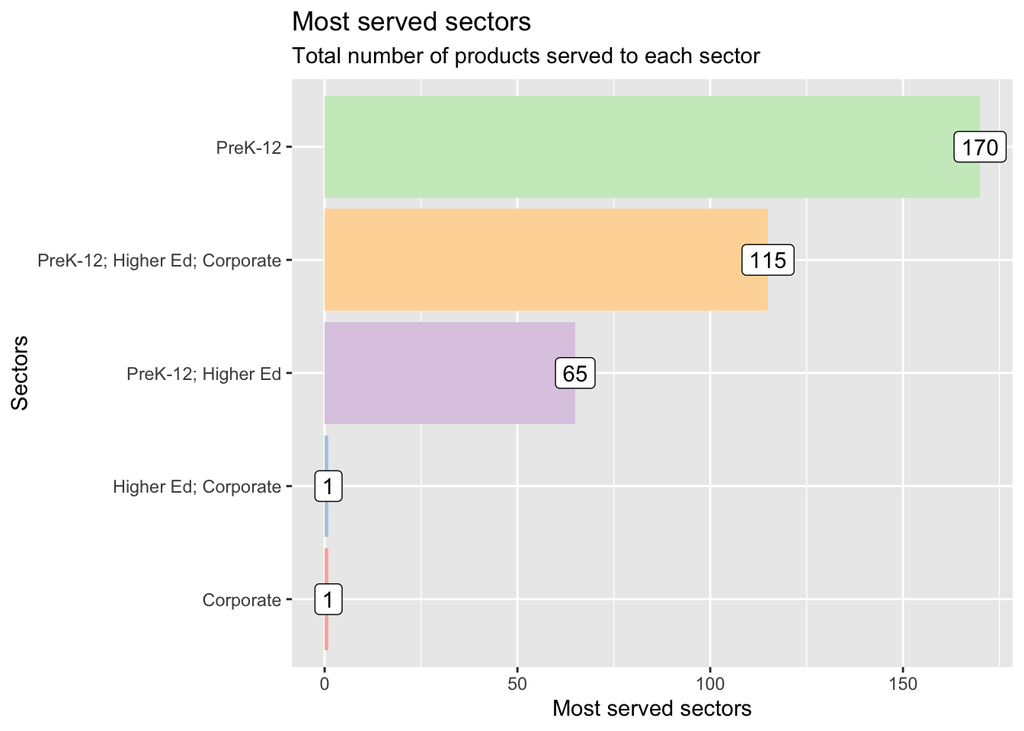

We can see that “PreK–12” appears 170 times in the data file, which shows that a sizable portion of digital learning materials are targeted towards K–12 students. This could be because most kids in the US have to go to school from K–12, and there is a high demand for digital learning resources to meet that need.

As the phrase “PreK–12; Higher Ed” only appears 65 times in the data file, the market for digital learning products aimed at K–12 and higher education is not very big. Because K–12 and higher education are two different markets with different needs and requirements, it may be harder to make products that work well in both.

Next we will see about the Primary Essential Functions

The pie chart is a useful visualization to show the proportion of each category in a dataset. In this case, we are showing the proportion of each primary essential function in the products_clean dataset. The pie chart is particularly useful in this case because we are interested in understanding the relative popularity of each primary essential function. By using a pie chart, we can easily see which functions are more popular and which are less popular, and we can also see the proportion of each function relative to the others.

[interactive chart not shown]

- The most popular product function is “LC - Digital Learning Platforms”, accounting for 28.5% of the total products.
- The second most popular function is “LC - Sites, Resources & Reference”, accounting for 18% of the total products.
- “LC - Content Creation & Curation” and “LC - Study Tools” are also popular, accounting for 13.8% and 9.5% of the total products, respectively.
- Other functions have a relatively smaller market share, with most accounting for less than 5% of the total products.

Overall, the data suggests that digital learning platforms and resources are the most in-demand product functions, with a significant proportion of products falling under these categories.

### District files

**Locale distribution**

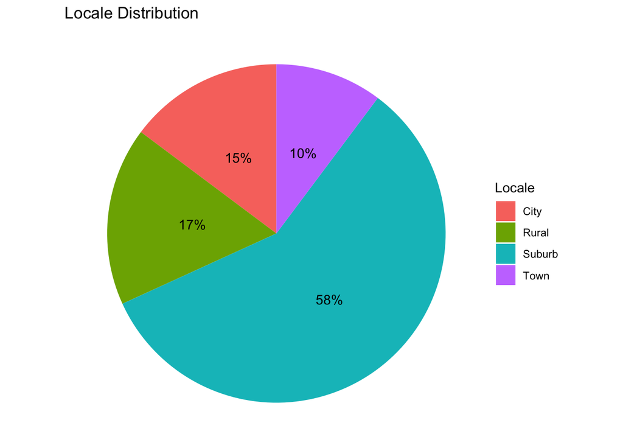

The chart shows that the majority of the dataset is located in suburban areas, with 58% falling into this category. This suggests that suburban areas are disproportionately represented in the dataset compared to other types of locations.

Moreover, the graph shows that only 17% of schools are located in rural areas, 15% in the city, and 10% in town. This could potentially be significant if there are important differences in digital learning outcomes or experiences between rural, city, town, and suburban areas.

**Percentage of Students Eligible for Free or Reduced-price Lunch**

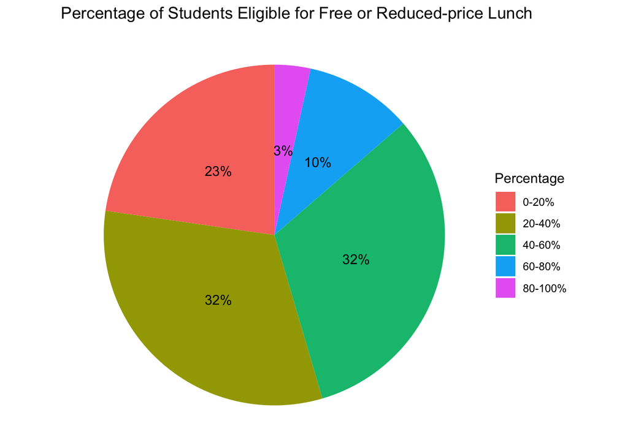

**Percentage of Black or Hispanic Students**

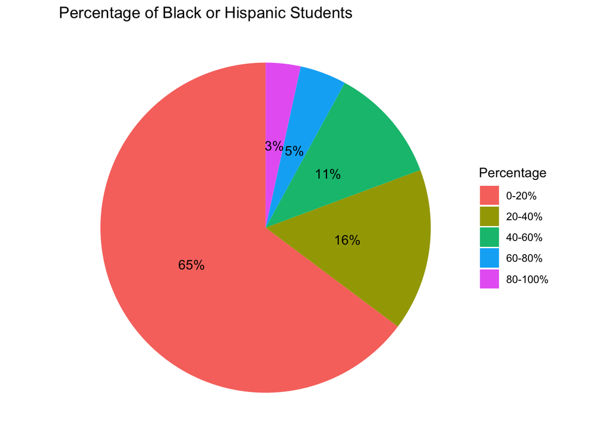

### Engagement files

For the engagement files, we aim to determine the most popular products that students have been using throughout the year 2020. To achieve this, we will need to analyze the data and identify the products that have been accessed the most by students during this time period.

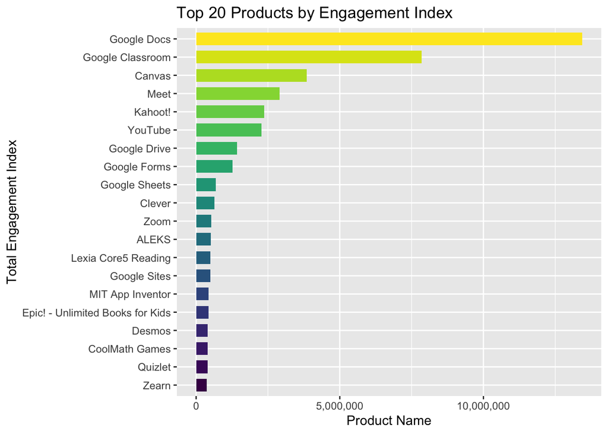

According to the engagement index in the chart, these are the top 20 digital learning tools that students will use the most in 2020. The engagement index is a metric that looks at how often and for how long students use a product to figure out how interested they are in it.

In the LearnPlatform COVID-19 Impact on Digital Learning we will analyze the engagement_index of students using various educational products throughout the year 2020. We will examine the changes in the engagement_index over the course of the month and identify any patterns or trends that may emerge.

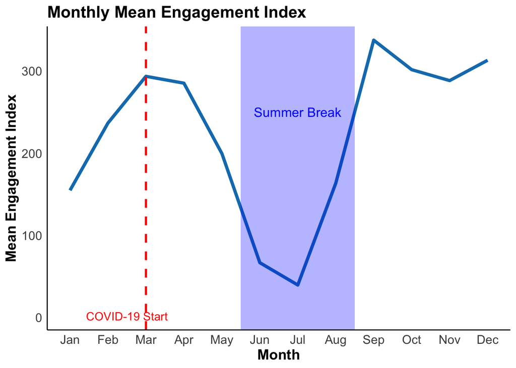